# Chapter 5 Practice

Pablo Bello

10/6/2022

```r
###--- Load libraries
library(tidyverse)
library(rethinking)
library(janitor)
library(dagitty)
library(tidybayes.rethinking)
library(ggpubr)
library(patchwork)
library(tidybayes)

theme_set(theme_pubr(border = TRUE) +
            theme(legend.title = element_blank()))
```

### 5E1

2 and 4 are multiple regressions.

### 5E2

$$\begin{aligned}
AnimalDiv_i &\sim \textrm{Normal}(\mu_i,\sigma) \\
\mu_i &= \alpha + \beta_lLatitude_i + \beta_pPlantDiv_i \\
\alpha &= 0 \\
\beta_l &\sim \textrm{Normal}(0,1) \\
\beta_p &\sim \textrm{Normal}(0,1) \\
\sigma &\sim \textrm{Uniform}(0,30)
\end{aligned}$$

### 5E3

Let P be the time to Ph.D. degree, F the amount of funding, and S the size of the lab. Both beta coefficients are expected to be positive according to the description of the problem. None of the predictors is strongly associated with the outcome but together they are, due to a negative correlation between them. This can be due to negative influence from one to the other or a prior variable causing both.

$$\begin{aligned}
P_i &\sim \textrm{Normal}(\mu_i,\sigma) \\
\mu_i &= \alpha + \beta_fF_i + \beta_sS_i \\
\alpha &= 0 \\
\beta_l &\sim \textrm{Lognormal}(0,1) \\
\beta_p &\sim \textrm{Lognormal}(0,1) \\
\sigma &\sim \textrm{Uniform}(0,30)
\end{aligned}$$

### 5E4

All but (2) are inferentially equivalent. They key is that they should have 4 different parameters (as many as categories in the indicator variable) and that each one of these should be multiplied by 1 with a different category. Model (2) has 5 parameters instead.

### 5M1

For a sample of kids let S be their shoe size, C the number of comics they own, and A their age. If we take S as the outcome, it should be correlated both with C and with A. But the true DAG is S <- A -> C (as they grow older kids have more chances to buy comics (C) and their feet grow as well (S)).

### 5M2

Let us imagine a sample of sociologists. Take scientific productivity (P) as an outcome. Then take the total number of books read (B) and the knowledge of stats (S) as predictors. In this case, B and S are correlated due to a prior variable, the disposition towards accumulating knowledge, or curiosity. But we can imagine the effect of B on P to be negative (reading books distracts you from producing papers). At the same time the effect of S on P can be positive (knowing more stats helps you produce papers).

### 5M3

If divorce rates are high, there is a bigger marriage market at any given time, thus making the marriage rate increase. With cross-sectional data multiple regression cannot get at the causal relationship between them. Longitudinal data would make it feasible.

### 5M4

```r
# Load divorce data
data(WaffleDivorce)
tbl <- as_tibble(WaffleDivorce)

# Load LDS data
lds_tbl <-
  read_csv("week_6/LDS_state.csv") |>
  clean_names()

# Clean up divorce data and join with lds data
tbl <-
  tbl |>
  transmute(
         state = Location,
         divorce = standardize(Divorce),
         marriage = standardize(Marriage),
         age_marriage = standardize(MedianAgeMarriage)) |>
  left_join(lds_tbl) |>
  drop_na() |>
  mutate(
    log_mormon = log(mormon_rate),
    mormon_rate = (mormon_rate - mean(mormon_rate))/sd(mormon_rate),
    log_mormon = standardize(log_mormon))


# Model
# Predict divorce rate using:
  #-Marriage Rate
  #-Median age at marriage
  #-Percet LDS population

model <- alist(
  divorce ~ dnorm(mu,sigma),
  mu <- alpha + beta_m * marriage + beta_a * age_marriage + beta_r * mormon_rate,
  alpha ~ dnorm(0, .2),
  beta_m ~ dnorm(0, .5),
  beta_a ~ dnorm(0, .5),
  beta_r ~ dnorm(0, .5),
  sigma ~ dexp(1)
)

model_f <- quap(model,data = tbl)
precis(model_f)
```

```
##                mean         sd       5.5%      94.5%
## alpha  -0.003323045 0.09360305 -0.1529188  0.1462727
## beta_m  0.033737299 0.15435217 -0.2129473  0.2804219
## beta_a -0.698368682 0.16778748 -0.9665255 -0.4302119
## beta_r -0.318608236 0.12275272 -0.5147908 -0.1224257
## sigma   0.738794413 0.07418832  0.6202272  0.8573617
```

The parameter for Mormon rate is negative with a mean of -.32 and .12 sd. States with a high proportion of Mormons have lower divorce rates once marriage rates and median age at marriage are taken into account.

### 5M5

Let us name the price of gas a G, obesity as O, exercise as E, and eating out as X. Then assume the following DAG is true.

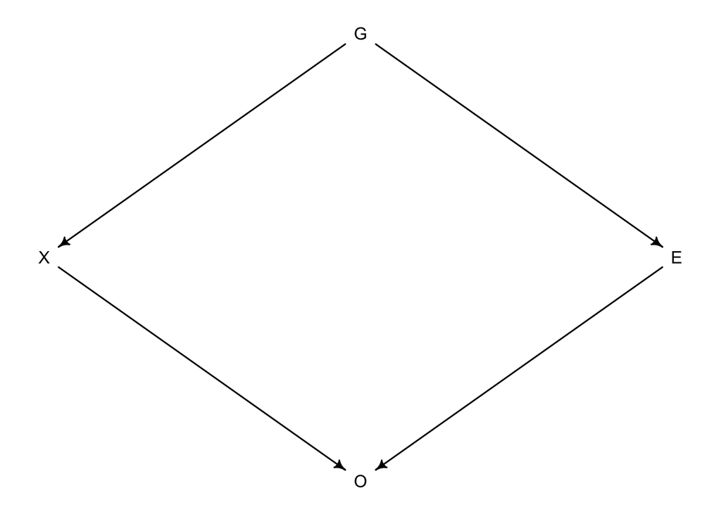

```r
###--- Drawing a DAG
dag <- dagitty("dag{G->X;G->E;X->O;E->O}")
coordinates(dag) <- list(x=c(G=1,X=0,E=2,O=1),y=c(G=0,X=1,E=1,O=2))
drawdag(dag)
```

```r
####--- Impliead conditional independencies
impliedConditionalIndependencies(dag)
```

```
## E _||_ X | G
## G _||_ O | E, X
```

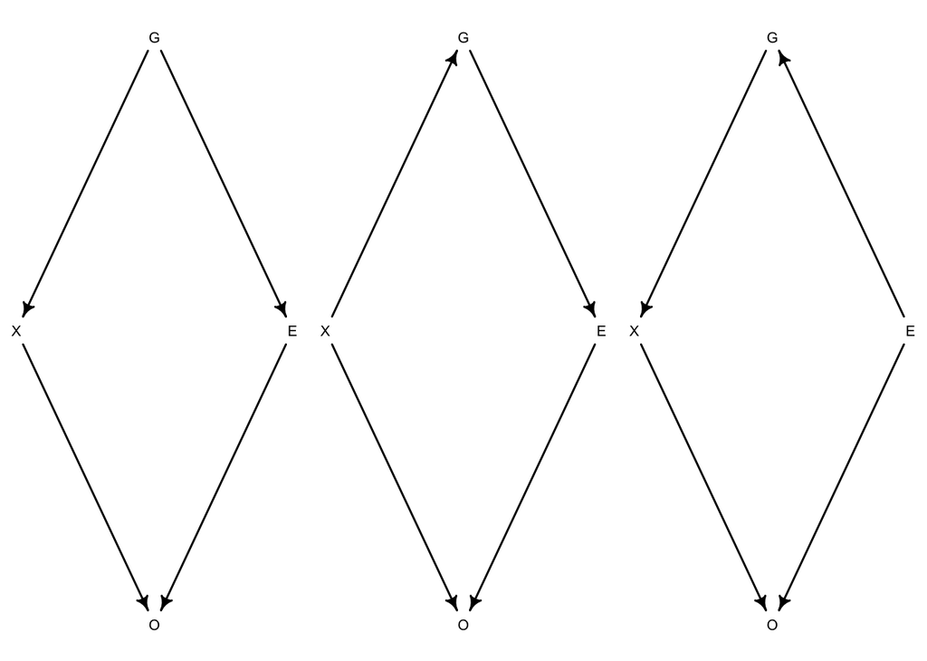

```r
###--- Markov Equivalence
MElist <- equivalentDAGs(dag)
drawdag(MElist)
```

We can see that the markov equivalence contains three DAGs, the proposed one and two more. However, the other two are unlikely as gas prices (G) are probably not affected by either eating out more or the amount of exercise people do. Although one can think of eating out increasing gas prices if that practice was to significantly increase the demand for gas.

### 5H1

```r
###--- Define the Dag
dag <- dagitty("dag{M->A;A->D}")

###--- Implied conditional independencies
impliedConditionalIndependencies(dag)
```

```
## D _||_ M | A
```

Given this DAG, D is independent of M given A. We would test this by running a model with D as outcome and M and A as predictors. If the affect of M is null then that conditional independency would hold.

```r
###--- Define the model
model <- alist(
  divorce ~ dnorm(mu,sigma),
  mu <- alpha + beta_m * marriage + beta_a * age_marriage,
  alpha ~ dnorm(0, .2),
  beta_m ~ dnorm(0, .5),
  beta_a ~ dnorm(0, .5),
  sigma ~ dexp(1)
)

###--- Fit the model
model_f <- quap(model,data = tbl)
precis(model_f)
```

```
##                mean         sd       5.5%      94.5%
## alpha   0.002167613 0.09883571 -0.1557909  0.1601262
## beta_m -0.057279893 0.15910314 -0.3115574  0.1969977
## beta_a -0.599234943 0.17417117 -0.8775941 -0.3208758
## sigma   0.793287685 0.07948836  0.6662499  0.9203254
```

In the model beta_m (the effect of marriage on divorce conditional on median age at marriag) is close to 0, so the data is consistent with the DAG. However, there other DAGs with the same conditional independencies that are plausible, so our statistical model cannot allocate between them. One could reason which one of these DAGs is more likely to be true if this was individual level data, but the fact that it is aggregated makes it more complicated to define plausible and non-plausible causal paths.

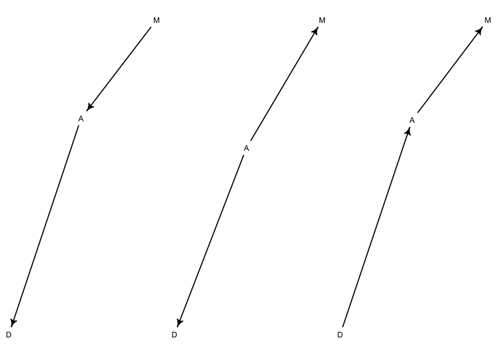

```r
###--- Markov Equivalence
MElist <- equivalentDAGs(dag)
drawdag(MElist)
```

### 5H2

```r
N <- 1000

###--- Define the model
model_2 <- alist(
  ###--- A->D
  divorce ~ dnorm(mu_d,sigma_d),
  mu_d <- alpha_d + beta_a * age_marriage,
  alpha_d ~ dnorm(0, .2),
  beta_a ~ dnorm(0, .5),
  sigma_d ~ dexp(1),

  ###--- M->A
  age_marriage ~ dnorm(mu_a,sigma_a),
  mu_a <- alpha_a + beta_m * marriage,
  alpha_a ~ dnorm(0, .2),
  beta_m ~ dnorm(0, .5),
  sigma_a ~ dexp(1)

)

###--- Fit the model
model_2f <- quap(model_2,data = tbl)
precis(model_2f)
```

```
##                 mean         sd       5.5%       94.5%
## alpha_d  0.003560341 0.09901174 -0.1546795  0.16180022
## beta_a  -0.554233161 0.12184732 -0.7489687 -0.35949761
## sigma_d  0.796060236 0.07956744  0.6688961  0.92322437
## alpha_a -0.043433056 0.07765998 -0.1675487  0.08068259
## beta_m  -0.669038451 0.08350459 -0.8024949 -0.53558198
## sigma_a  0.589766093 0.05911731  0.4952852  0.68424698
```

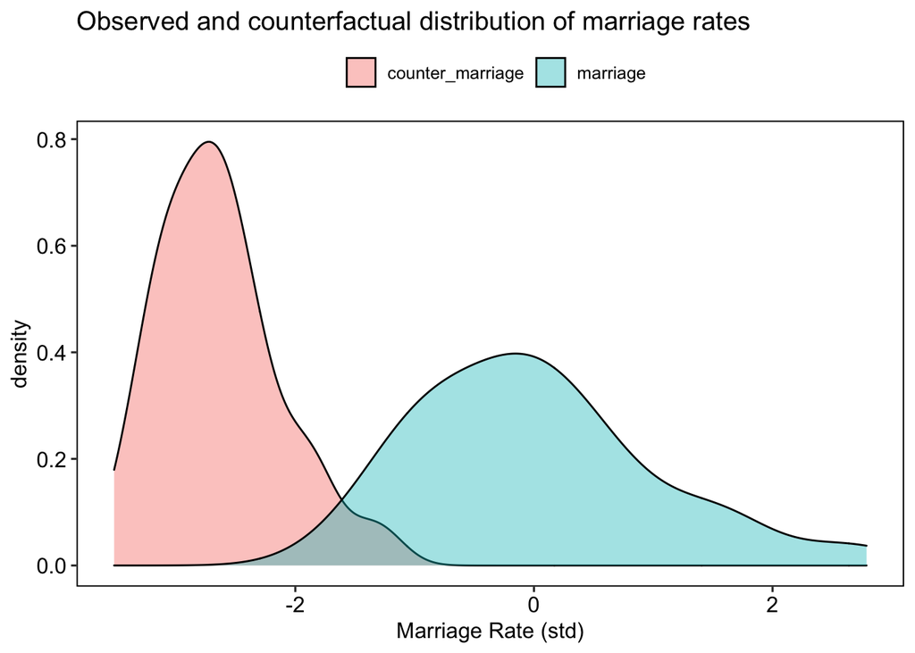

```r
###--- Get some draws from the posterior
post_draws <-
  tidy_draws(model_2f,n = nrow(tbl)*N*2) |>
  select(!starts_with("."))

###--- Create a tibble with real and counterfactual values

  ###--- I need to de-estandardize first, then standardize w the same sd and mean.
  d <- as_tibble(WaffleDivorce)
  mean <- mean(d$Marriage)
  sd <- sd(d$Marriage)

  counter_tbl <-
    tbl |>
    select(marriage) |>
    mutate(counter_marriage = marriage * sd + mean, # de-estandardize
           counter_marriage = counter_marriage/2, # Divide by two
           counter_marriage = (counter_marriage - mean)/sd) |> # Standardize again on   the same scale
    pivot_longer(cols = c(marriage, counter_marriage),names_to = "type",values_to = "marriage_rate")


  ###--- Check real and counterfactual
  counter_tbl |>
    ggplot(aes(marriage_rate, fill = type)) +
    geom_density(alpha = .4) +
    labs(title = "Observed and counterfactual distribution of marriage rates",
         x = "Marriage Rate (std)")
```

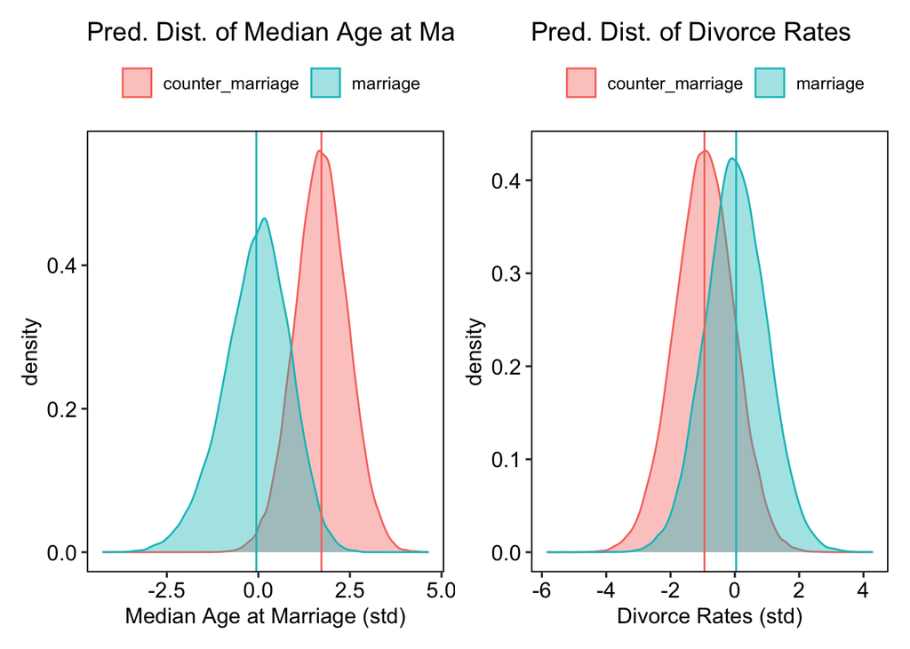

```r
  ###--- Make predictions
  pred_tbl <-
    counter_tbl |>
    mutate(id = row_number()) |>
    uncount(N) |>
    bind_cols(post_draws) |>
    rowwise() |>
    mutate(age_m_pred = rnorm(1,alpha_a + beta_m * marriage_rate,sigma_a),
           divorce_pred = rnorm(1,alpha_d + beta_a * age_m_pred, sigma_d))


 ###--- Effect on age predictions
  p1 <-
    pred_tbl |>
    select(age_m_pred,type) |>
    group_by(type) |>
    mutate(mean = mean(age_m_pred)) |>
    ggplot(aes(age_m_pred, group = type, fill = type, color = type)) +
    geom_density(alpha = .4) +
    geom_vline(aes(xintercept = mean, color = type),show.legend = FALSE) +
    labs(title = "Pred. Dist. of Median Age at Marriage",
         x = "Median Age at Marriage (std)")



  ###--- Effect on divorce rates
  p2 <-
    pred_tbl |>
    select(divorce_pred,type) |>
    group_by(type) |>
    mutate(mean = mean(divorce_pred)) |>
    ggplot(aes(divorce_pred, group = type, fill = type, color = type)) +
    geom_density(alpha = .4) +
    geom_vline(aes(xintercept = mean, color = type), show.legend = FALSE) +
    labs(title = "Pred. Dist. of Divorce Rates",
         x = "Divorce Rates (std)")

  ###--- Plot them together
  p1 + p2
```

```r
  #+ patchwork::plot_layout(nrow = 2)
```

### 5H3

```r
###--- Load the milk data
  data(milk)

  tbl <-
    milk |>
    as_tibble() |>
    clean_names() |>
    transmute(
           kcal = standardize(kcal_per_g),
           neo = standardize(neocortex_perc),
           mass = standardize(mass)) |>
    drop_na()


###--- Now both mass and neocortex as predictors
  model <- alist(
    ###--- mass->Kcal<-neo
    kcal ~ dnorm(mu_k,sigma_k),
    mu_k <- alpha_k + beta_n * neo + beta_m * mass,
    alpha_k ~ dnorm(0,.2),
    beta_n ~ dnorm(0,.5),
    beta_m ~ dnorm(0,.5),
    sigma_k ~ dexp(1),

    ###--- mass -> neo
    neo ~ dnorm(mu_n,sigma_n),
    mu_n <- alpha_n + beta_m2 * mass,
    alpha_n ~ dnorm(0,.2),
    beta_m2 ~ dnorm(0,.5),
    sigma_n ~ dexp(1)

  )

###--- Fit the model
  model_f <- quap(model, data = tbl)
  precis(model_f)
```

```
##                mean        sd        5.5%      94.5%
## alpha_k  0.06959757 0.1437680 -0.16017154  0.2993667
## beta_n   0.42039061 0.2322485  0.04921271  0.7915685
## beta_m  -0.56045480 0.2432231 -0.94917231 -0.1717373
## sigma_k  0.84041651 0.1448687  0.60888836  1.0719447
## alpha_n -0.02342139 0.1351828 -0.23946968  0.1926269
## beta_m2  0.55695258 0.1854291  0.26060110  0.8533041
## sigma_n  0.75320332 0.1263247  0.55131199  0.9550946
```

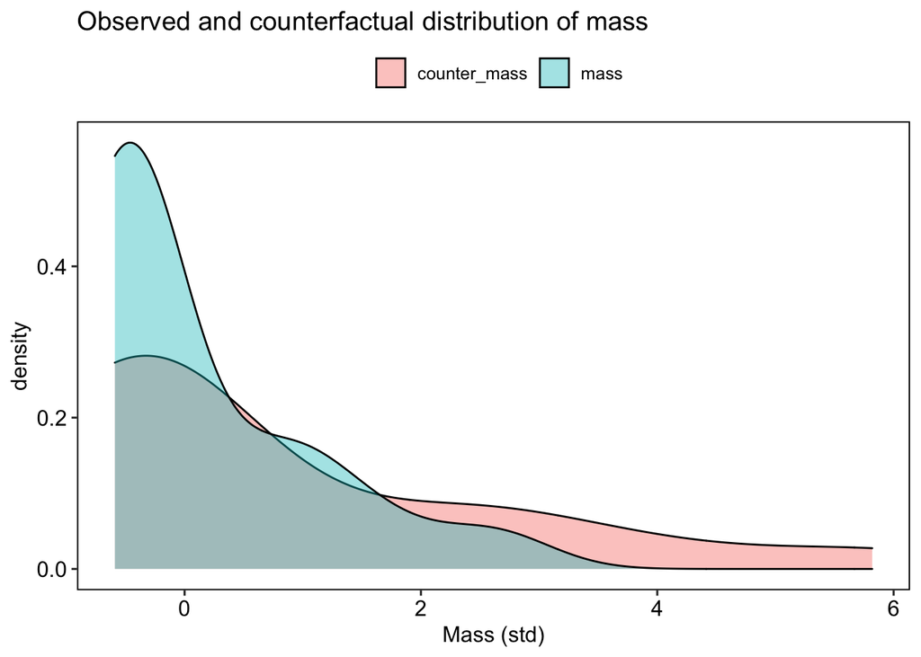

```r
###--- Get some draws from the posterior
  post_draws <-
    tidy_draws(model_f,n = nrow(tbl)*N*2) |>
    select(!starts_with("."))


###--- Construct a tibble w counterfactuals
  d <- as_tibble(milk)
  mean <- mean(d$mass)
  sd <- sd(d$mass)

  counter_tbl <-
    tbl |>
    select(mass) |>
    mutate(counter_mass = mass * sd + mean, # de-estandardize
           counter_mass = counter_mass*2, # Multiply by two
           counter_mass = (counter_mass - mean)/sd) |> # Standardize again on   the same scale
    pivot_longer(cols = c(mass, counter_mass),names_to = "type",values_to = "mass")

###--- Check real and counterfactual
  counter_tbl |>
    ggplot(aes(mass, fill = type)) +
    geom_density(alpha = .4) +
    labs(title = "Observed and counterfactual distribution of mass",
         x = "Mass (std)")
```

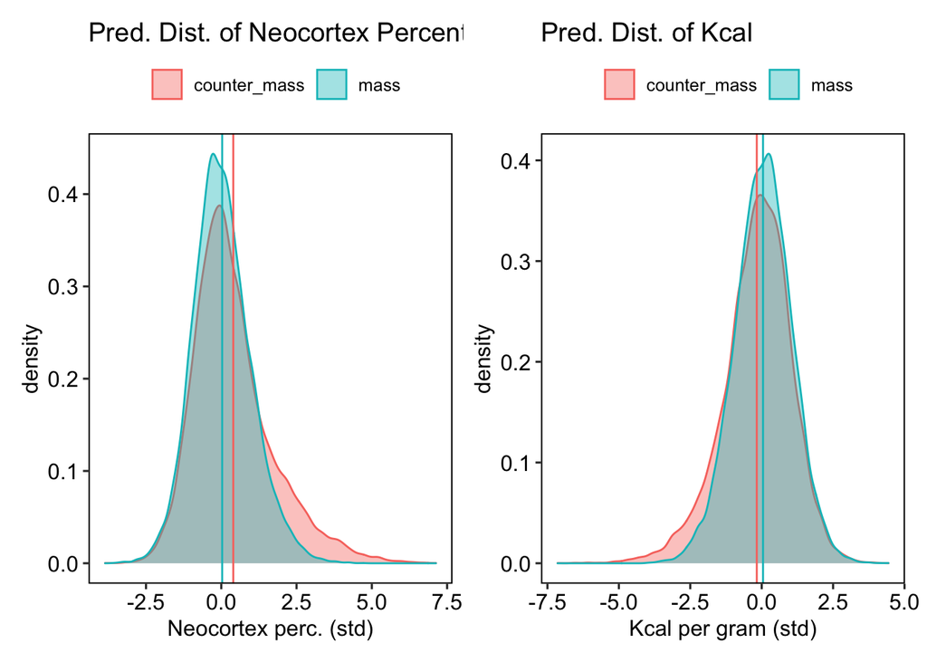

```r
###--- Make predictions
  pred_tbl <-
    counter_tbl |>
    mutate(id = row_number()) |>
    uncount(N) |>
    bind_cols(post_draws) |>
    rowwise() |>
    mutate(neo_pred = rnorm(1,alpha_n + beta_m2 * mass,sigma_n),
           kcal_pred = rnorm(1,alpha_k + beta_n * neo_pred + beta_m * mass, sigma_k))


 ###--- Effect of doubling mass on neo cortex percentage
  p3 <-
    pred_tbl |>
    select(neo_pred,type) |>
    group_by(type) |>
    mutate(mean = mean(neo_pred)) |>
    ggplot(aes(neo_pred, group = type, fill = type, color = type)) +
    geom_density(alpha = .4) +
    geom_vline(aes(xintercept = mean, color = type),show.legend = FALSE) +
    labs(title = "Pred. Dist. of Neocortex Percent",
         x = "Neocortex perc. (std)")



  ###--- Effect of doubling mass on kcal in milk (direct and indirect effect)
  p4 <-
    pred_tbl |>
    select(kcal_pred,type) |>
    group_by(type) |>
    mutate(mean = mean(kcal_pred)) |>
    ggplot(aes(kcal_pred, group = type, fill = type, color = type)) +
    geom_density(alpha = .4) +
    geom_vline(aes(xintercept = mean, color = type),show.legend = FALSE) +
    labs(title = "Pred. Dist. of Kcal",
         x = "Kcal per gram (std)")

  ###--- Put them together
  p3 + p4
```

The direct effect of mass on kcal is negative but the indirect effect is positive. Mass has a positive effect on neocortex and neocortex has a positive effect on kcal in milk. As we can see the result is that the predicted mean of the distribution of kcal per gram of milk is a bit lower when we double mass but not so much so (because of the counteracting indirect effect).

### 5H4

I think “southerness” could have a direct effect on all three of these variables. People in the south would tend to get married earlier (S -> A), more people would get married (S -> M) and, all else equal, less likely to get a divorce (S -> D). If this was true, southerness would have a direct effect on divorce rates and two indirect effects. But in this model there would be no new conditional independencies to test (because S would have an effect on every other variable).

For the sake of the exercise I will assume S does not have a direct effect on D. From previous models we know that D is independent of M given A, so I omit that arrow. The resulting model is presented as a DAG. Given this model, we should observe two conditional independencies. D is independent of M given A, which we have proved before. D is independent of S given A, which we have not tested, so I will do that.

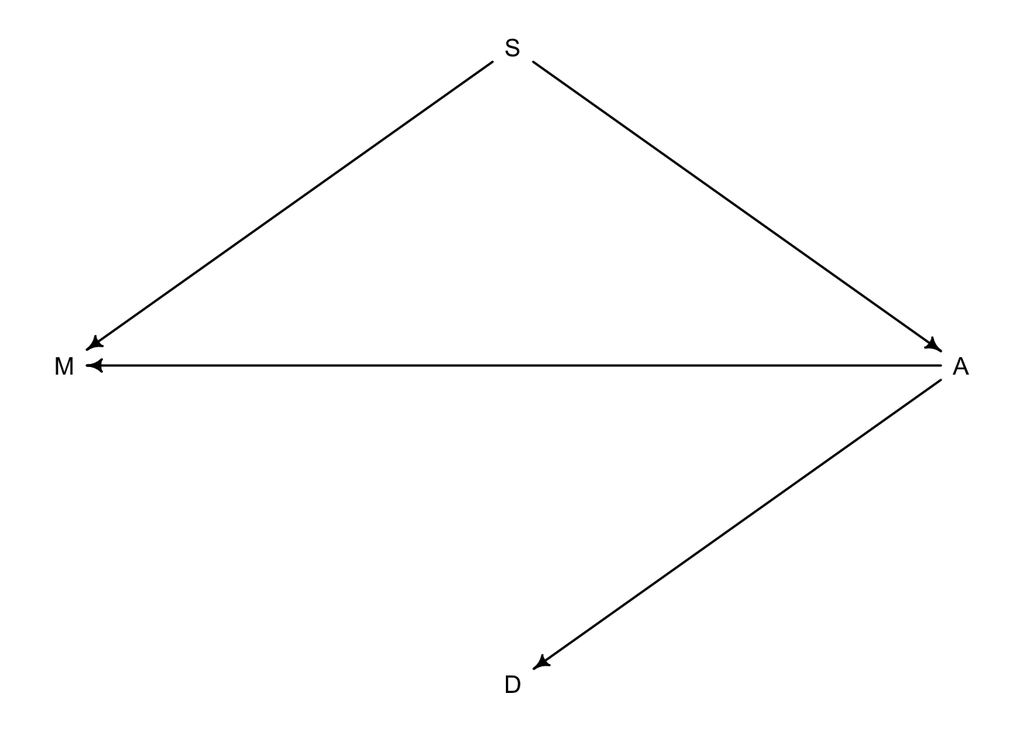

```r
###--- DAG 2
dag <- dagitty("dag{S->M;A->M;A->D;S->A}")
coordinates(dag) <- list(x=c(S=1,M=0,A=2,D=1),y=c(S=0,M=1,A=1,D=2))
drawdag(dag)
```

```r
####--- Impliead conditional independencies
impliedConditionalIndependencies(dag)
```

```
## D _||_ M | A
## D _||_ S | A
```

```r
###--- Test implications of the model
  ###--- Load the data  again
  data(WaffleDivorce)
  tbl <-
    WaffleDivorce |>
    as_tibble() |>
    transmute(
           state = Location,
           divorce = standardize(Divorce),
           marriage = standardize(Marriage),
           age_marriage = standardize(MedianAgeMarriage),
           south = South) |>
    drop_na()


  ###--- Let's test the conditonal independence of D on S given A
  model <- alist(
    divorce ~ dnorm(mu,sigma),
    mu <- alpha + beta_a * age_marriage + beta_s * south,
    alpha ~ dnorm(0, .2),
    beta_a ~ dnorm(0, .5),
    beta_s ~ dnorm(0, .5),
    sigma ~ dexp(1)
  )

  model_f <- quap(model,data = tbl)
  precis(model_f)
```

```
##               mean         sd        5.5%       94.5%
## alpha  -0.07720383 0.10604741 -0.24668807  0.09228041
## beta_a -0.53179303 0.10918479 -0.70629141 -0.35729465
## beta_s  0.35627168 0.21489793  0.01282328  0.69972008
## sigma   0.76436944 0.07587969  0.64309904  0.88563983
```

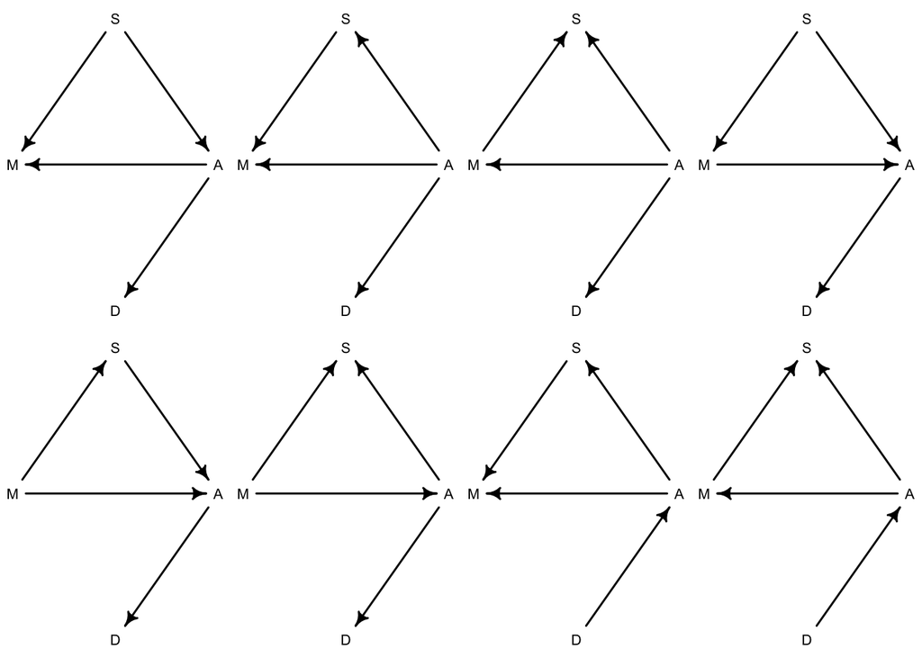

```r
###--- Markov Equivalence
MElist <- equivalentDAGs(dag)
drawdag(MElist)
```